# Predicting Heart Disease

Author: Walter Guillioli

September 09, 2024

## Introduction

Unfortunately, cardiovascular diseases are the world’s most common cause of death. The motivation of this project is to understand if we can predict the presence or absence of heart disease in people given basic medical information. This is a very personal project for me due to the disease history in my family - including my father.

In this project, we will look at a relatively simple dataset of 270 patients. We will first import and explore the data and then we will prepare it to apply different algorithms that will allow us to understand what can help predict a heart disease.

This file is just a summary. To see all the code and all the work behind the scenes see this [file](https://github.com/wguillioli/heart_disease/blob/main/scripts/heart_disease_ms.Rmd).

## Data and Methods

The dataset was obtained from a study of heart disease that has been open to the public for many years. The study collects various measurements of patient health and cardiovascular statistics. It is a relatively small dataset with data for 270 patients and 13 variables of information for each patient. There is an additional binary variable that indicates the absence or presence of heart disease and that is the variable we will attempt to predict.

In total, there are 270 patients. Of those, 120 (44%) have heart disease and 150 (56%) do not have heart disease. Note that no missing values are present in the data.

The 13 available attributes of each patient are summarized in the table below. For more details see the competition page on [drivendata.org](https://www.drivendata.org/competitions/54/machine-learning-with-a-heart/page/109/).

| Attribute | Summary |
| --- | --- |
| Patient’s age | Numeric, from 29 to 77 years |
| Patient’s gender | Binary, 68% males, 32% females |
| Chest pain type | Categorical, 4 possible values |
| Resting blood pressure | Numeric, from 94 to 200 |
| Serum cholestorol in mg/dl | Numeric, from 126 to 564 |
| Fasting blood sugar | Binary, indicating if blood sugar > 120 mg/dl |
| Resting electrocardiographic results | Categorical, 3 possible values |
| Maximum heart rate (beats per minute) | Numeric, from 71 to 202 |
| Exercise-induced chest pain (angina) | Binary, indicating if exercise produces pain |
| ST depression induced by exercise relative to rest | Numeric, from 0 to 6.2 (most are zero) |
| Slope of the peak exercise ST segment | Categorical, 3 possible values |
| Number of major vessels colored by flouroroscopy | Categorical, 4 possible values |
| Results of thallium stress test | Categorical, 3 possible values |

Since we have a manageable number of variables for each patient, a detailed univariate exploratory analysis is performed to understand the details of the variable and more importantly to understand the potential prediction power of the absence or presence of heart disease.

Specifically, for numerical variables I explore the distribution of the data. Where appropriate I cap the observations at a particular percentile in order the make the distribution of the data “more normal”. In other cases, a transformation of scale (logarithmic for example) is performed.

For discrete variables, I am mostly concerned about differences in the proportion of patients that have or don’t have heart disease as it relates to the variable. If the counts of a particular value of these discrete variables are too low I perform groupings to help the ML algorithms we will use.

As an example let’s look at one example of each variable here.

### Maximum heart rate achieved (beats per minute)

The number of beats per minute per patient ranges from 71 to 202 with a median of 153. The data is mostly normally distributed, as seen in the chart below.

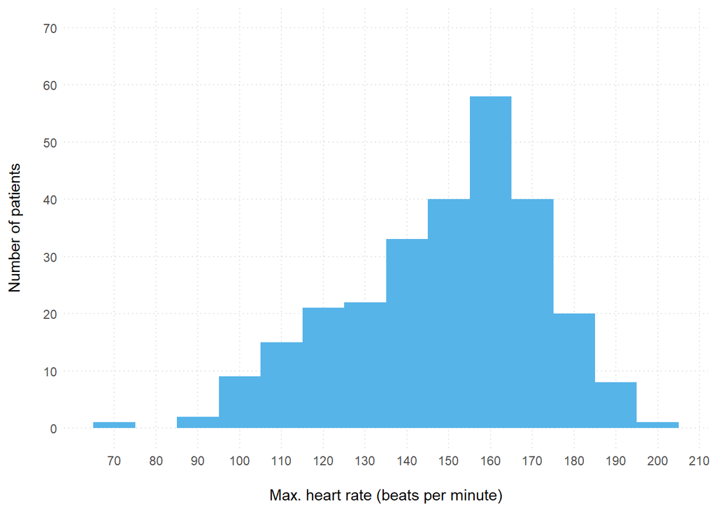

More importantly, we see a really good potential for prediction of maximum heart rate where patients with heart disease have a median of 141 vs 161 for those that don’t have heart disease. It is also important to note that for patients with heart disease the middle half of the observations (percentile 25 to 75) range from 125 to 157, vs 148 to 174 for those without a heart disease. This image shows this distribution.

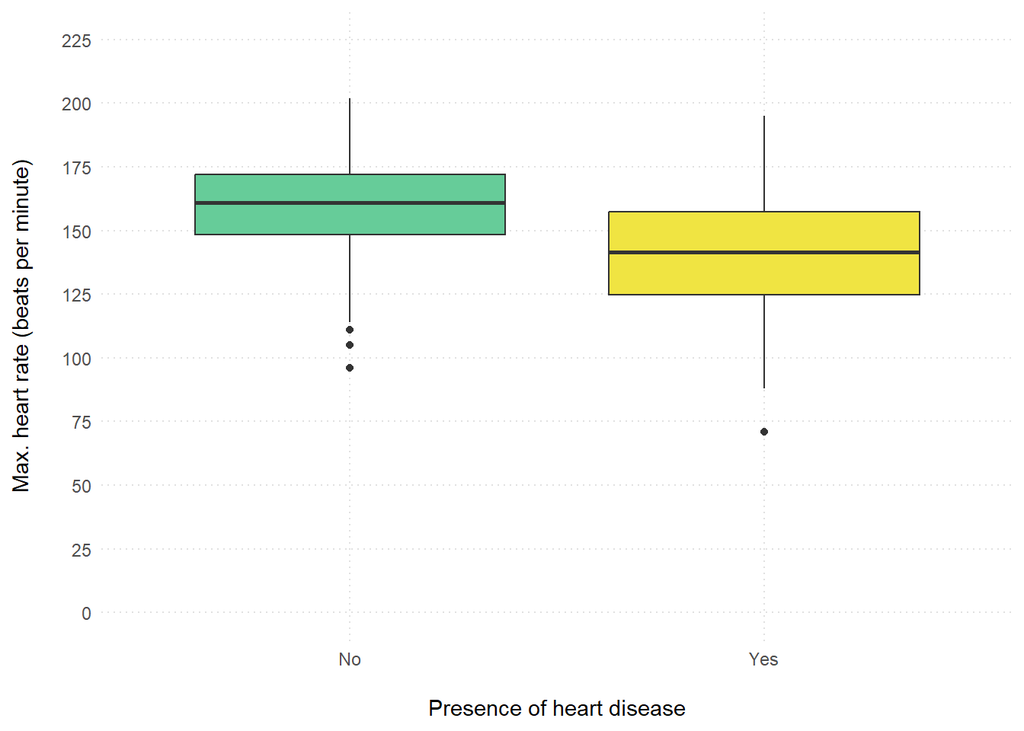

### Results of thallium stress test

Test that measures the blood flow to the heart, with possible values normal, fixed_defect, reversible_defect.

|  | 3 (Normal) | 6 (Fixed) | 7 (Reversable) |
| --- | --- | --- | --- |
| No | 119 | 6 | 25 |
| Yes | 33 | 8 | 79 |

[output not shown]

### Relationship within the attributes (Multicollinearity)

Another interesting thing is to see what variables are related to each other. This is important to understand the predictors and might need to be addressed. The chart below shows us the correlation values of the numerical variables of the patients. We are interested in big squares which means bigger correlations.

For example, looking at the patient’s age we see a relatively strong correlation between the number of vessels colored by fluoroscopy and the patient’s blood pressure. In layman’s terms for the latter, we could say that older patients tend to have higher blood pressure.

In addition, we are interested in negative correlations (the red squares). For example, we can see that older patients tend to have lower maximum heart rates - which makes sense.

The slope of the peak exercise ST segment and ST depression induced by exercise relative to rest have a very high correlation of 0.6. The variables seem to measure similar information so one could be removed but will leave it for now.

Chest pain and exercise-induced pain (angina) are highly correlated. And as we will see they are very strong predictors of heart disease.

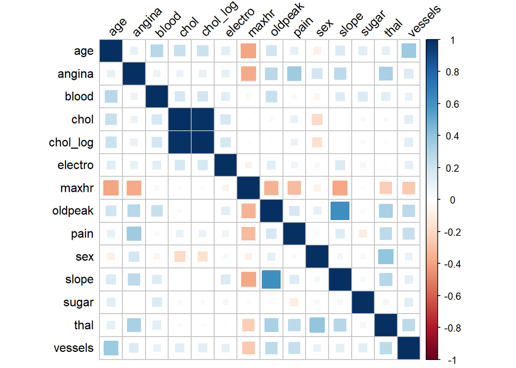

## Results

Alternatively, there are a couple of unexpected results worth mentioning

- **Serum cholesterol in mg/dl**: there wasn’t much difference in cholesterol values for patients with or without disease and this contradicts what I had expected.
- **Fasting blood sugar**: same as cholesterol there are no major differences across both groups of patients.

Now, let’s compare our manual work with the automated work of ML algorithms and see what results are obtained.

### Model results

In total, we performed three different ML models to predict the presence of heart disease.

1. Random Forest using the train/test validation approach to test the model on new data. I especially like this technique because it gives us a clear sense of what attributes are good predictors.
2. Logistic regression using train/test validation approach like in the previews model.
3. Random Forest using cross-validation. The idea here is to go beyond a simple random forest and let the algorithm explore different tuning parameters and in a way help us pick the best model. Interestingly it didn’t change much.

The results are summarized in the table below. We see all three are close to 80% in accuracy so the immediate question is, is that good or bad? Certainly, the results could be improved potentially if we tried different algorithms but that is not the goal here.

Considering that our dataset had 120 (44%) patients with heart disease and 150 (56%) without we see a very balanced dataset that was almost like flipping a coin. If we had said that all patients don’t have heart disease we would be correct 56%. So these algorithms getting us to around 80% accuracy is a huge improvement.

| Modeling technique | Accuracy |
| --- | --- |
| Random Forest (train/test) | 0.76 |
| Logistic Regression (forward selection) | 0.81 |
| Random Forest (cross validation) | 0.81 |

### Important attributes predicting heart disease

One of the advantages of the Random Forest algorithm is that it ranks what variables are the most important in building all the trees. This is summarized here:

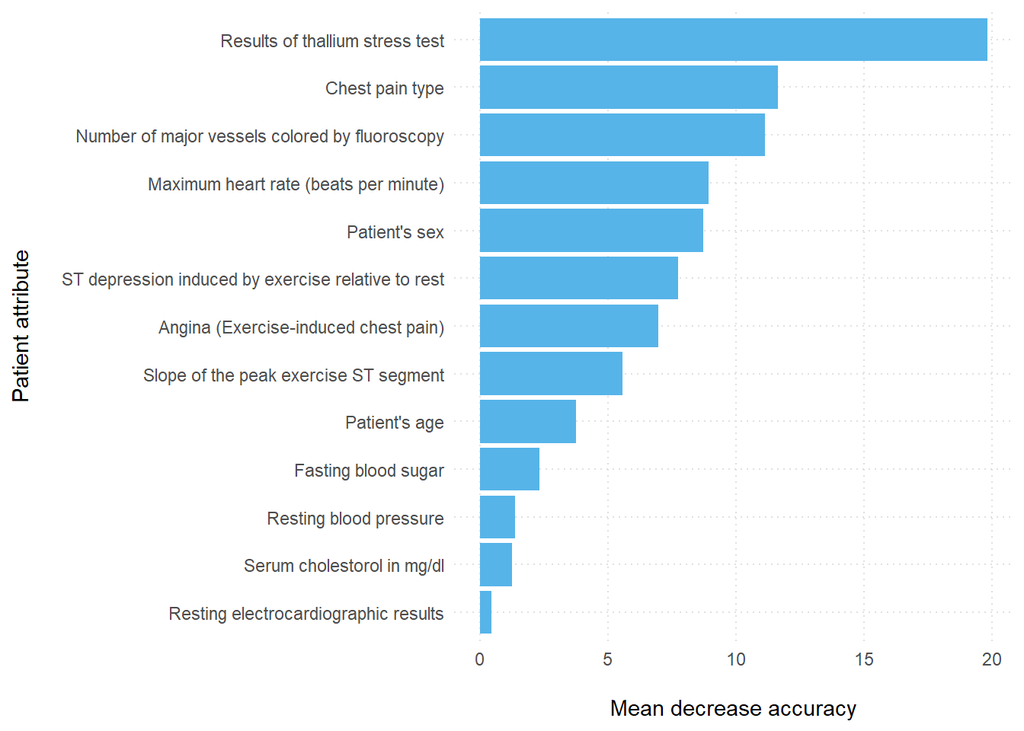

### Another approach to explain the model

The previous results are great to get a sense of the importance of the variables. But the next question is how. For that, we used a very simple classification tree that allows us to see some of the rules behind the trees to determine the presence of heart disease.

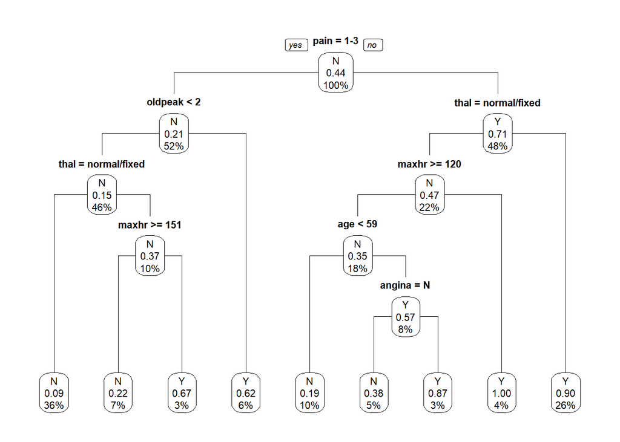

## Conclusions

1. Based on this simple dataset it seems that understanding what can cause the presence of heart disease is not that complex and there are simple measures we can take
2. Algorithms only provide partial solutions and we should not take them as the ultimate truth. For example, we know that many other variables are good potential predictors but the tree did not show them for example.
3. More data would be nice to explore different or complementary results. For example, it is a bit strange that Resting blood pressure and Serum cholesterol in mg/dl did not appear as strong predictors.

## References

DrivenData. (n.d.). Warm-up: Machine learning with a heart. http://www.drivendata.org/competitions/54/machine-learning-with-a-heart

Statlog (heart). UCI Machine Learning Repository. (n.d.). https://doi.org/10.24432/C57303

Cardiovascular diseases - global facts and figures. World Heart Federation. (2023, May 26). https://world-heart-federation.org/resource/cardiovascular-diseases-cvds-global-facts-figures/

Barter, R. (2020, April 14). Tidymodels: Tidy Machine Learning in R. Rebecca Barter. https://rebeccabarter.com/blog/2020-03-25_machine_learning